# French MTPL GLM vs LightGBM Comparison

# Executive Result

The actuarial objective is to estimate expected annual loss cost:

```
expected annual pure premium = expected annual claim frequency * expected claim severity
```

The GLM is the benchmark. LightGBM is the challenger. The useful question is not whether the boosted model produces a nicer metric in isolation; it is whether it improves risk segmentation, calibration, or interaction discovery enough to justify the extra complexity.

On this holdout split, the useful result is mixed but informative:

- the GLM remains excellent on aggregate frequency calibration: it predicted 3,233.8 claims versus 3,240 observed, a -0.2% gap
- LightGBM is slightly worse on aggregate frequency calibration, predicting 3,226.2 claims, but it improves frequency ranking from Gini 0.1466 to 0.1816
- raw pure premium Gini improves from 0.2366 for the GLM to 0.3957 for LightGBM, a 67.3% relative lift
- LightGBM underpredicts aggregate pure premium more than the GLM, so its value is stronger as a segmentation and feature-discovery model than as an unadjusted pricing level
- the severity cap used for the sensitivity view is EUR 36,876

```r
knitr::kable(results$model_value)
```

| question | answer |
| --- | --- |
| Did GBM rank frequency risk better? | Yes, frequency Gini improved meaningfully. |
| Did GBM rank pure premium risk better? | Yes, pure-premium Gini improved meaningfully. |
| Did GBM materially simplify the severity problem? | No. Severity remains tail-sensitive, so raw and capped views should both be shown. |
| What is the main use of GBM here? | Use it as a challenger model and interaction-discovery tool, not as an automatic replacement for the GLM. |

```r
knitr::kable(business_summary)
```

| question | result | implication |
| --- | --- | --- |
| Frequency calibration | GLM missed holdout claims by -0.2%; LightGBM missed by -0.4%. | The GLM remains the cleaner aggregate frequency benchmark. |
| Frequency ranking | LightGBM frequency Gini improved by 0.035 points, or 23.9%. | LightGBM finds additional segmentation signal in claim frequency. |
| Severity calibration | Raw severity remains weak: GLM mean gap -15.8%; LightGBM mean gap -24.3%. | Neither model solves large-loss volatility; severity needs cautious interpretation. |
| Severity error | LightGBM lowered raw severity MAE by 7.0% and capped severity MAE by 1.9%. | LightGBM helps error modestly, especially in the body of the severity distribution. |
| Pure premium ranking | LightGBM raw pure premium Gini improved by 0.1591 points, or 67.3%. | The challenger is materially better at ordering policies by observed loss cost. |
| Pure premium calibration | Raw pure premium is undercalibrated: GLM gap -14.8%; LightGBM gap -24.6%. | LightGBM needs calibration before being used as a direct pricing level. |

# Data And Split

This comparison reuses the same policy-level train/holdout split from the GLM project. That matters because the goal is a fair challenger comparison, not a new experiment with a different split.

```r
knitr::kable(round_table(checks))
```

| metric | value |
| --- | --- |
| policy_rows_raw | 413169.0 |
| policy_rows_after_cleaning | 413169.0 |
| claim_rows_raw | 16181.0 |
| claim_rows_after_cleaning | 16181.0 |
| train_policies | 330535.0 |
| holdout_policies | 82634.0 |
| train_claim_rows | 12941.0 |
| holdout_claim_rows | 3240.0 |
| gbm_fit_policies | 264427.0 |
| gbm_validation_policies | 66108.0 |
| gbm_fit_claim_rows | 10348.0 |
| gbm_validation_claim_rows | 2593.0 |
| train_holdout_policy_leakage | 0.0 |
| gbm_fit_validation_policy_leakage | 0.0 |
| observed_loss_reconciliation_gap | 0.0 |
| severity_cap_99_5 | 36876.2 |

The leakage checks should be zero. The observed-loss reconciliation gap should also be zero because pure premium validation depends on matching policy-level losses back to the severity file.

# Modeling Setup

The GLM benchmark stays actuarially classical:

- Poisson frequency with an exposure offset
- Gamma severity on positive claim rows
- pure premium derived as frequency times severity

The LightGBM challenger mirrors that structure:

- Poisson objective on annual claim frequency, weighted by exposure
- Gamma objective for raw severity
- Gamma objective for 99.5% capped severity
- pure premium derived from the frequency model and severity model

The holdout set is not used for tuning. LightGBM uses a small validation split inside the training set with early stopping.

```r
tuning_all <- rbind(
  cbind(component = "Frequency", results$tuning$frequency),
  cbind(component = "Raw severity", results$tuning$severity),
  cbind(component = "Capped severity", results$tuning$capped_severity)
)
knitr::kable(round_table(tuning_all))
```

| component | candidate | objective | validation_deviance | best_iter | num_leaves | min_data_in_leaf | learning_rate | feature_fraction | bagging_fraction | lambda_l2 |
| --- | --- | --- | --- | --- | --- | --- | --- | --- | --- | --- |
| Frequency | 1 | poisson | 0.4454 | 265 | 15 | 1000 | 0.05 | 0.9 | 0.9 | 1 |
| Frequency | 2 | poisson | 0.4455 | 278 | 31 | 1000 | 0.03 | 0.9 | 0.9 | 1 |
| Frequency | 3 | poisson | 0.4455 | 136 | 31 | 500 | 0.05 | 0.8 | 0.8 | 5 |
| Frequency | 4 | poisson | 0.4454 | 108 | 15 | 500 | 0.08 | 0.8 | 0.9 | 3 |
| Raw severity | 1 | gamma | 1.3356 | 17 | 7 | 100 | 0.05 | 0.9 | 0.9 | 1 |
| Raw severity | 2 | gamma | 1.3302 | 39 | 15 | 100 | 0.03 | 0.9 | 0.9 | 1 |
| Raw severity | 3 | gamma | 1.3266 | 15 | 15 | 50 | 0.05 | 0.8 | 0.8 | 5 |
| Raw severity | 4 | gamma | 1.3253 | 34 | 31 | 100 | 0.03 | 0.8 | 0.9 | 5 |
| Capped severity | 1 | gamma | 1.1259 | 23 | 7 | 100 | 0.05 | 0.9 | 0.9 | 1 |
| Capped severity | 2 | gamma | 1.1268 | 23 | 15 | 100 | 0.03 | 0.9 | 0.9 | 1 |
| Capped severity | 3 | gamma | 1.1254 | 19 | 15 | 50 | 0.05 | 0.8 | 0.8 | 5 |
| Capped severity | 4 | gamma | 1.1270 | 11 | 31 | 100 | 0.03 | 0.8 | 0.9 | 5 |

# Frequency

Frequency is usually the cleanest place for this dataset to show signal. The key actuarial checks are aggregate calibration, error on annual frequency, and whether the model ranks higher-frequency risks better.

```r
knitr::kable(round_table(frequency_comparison))
```

| model | observed_claims | predicted_claims | observed_annual_frequency | predicted_annual_frequency | weighted_mae_annual_frequency | weighted_rmse_annual_frequency | pricing_lift_gini |
| --- | --- | --- | --- | --- | --- | --- | --- |
| GLM | 3240 | 3233.804 | 0.0699 | 0.0698 | 0.1327 | 0.4694 | 0.1466 |
| LightGBM | 3240 | 3226.221 | 0.0699 | 0.0696 | 0.1322 | 0.4689 | 0.1816 |

The frequency result is the best argument for the GBM challenger. The GLM is almost perfectly calibrated in aggregate, missing holdout claim count by only -0.2%. LightGBM misses by -0.4%, so it does not beat the GLM on total claim count. But LightGBM improves the ranking Gini by 0.035 points, or 23.9% relative to the GLM. In actuarial terms, that means the GBM is better at sorting policies into higher- and lower-frequency risk groups, even though the GLM is already strong for aggregate expected claim count.

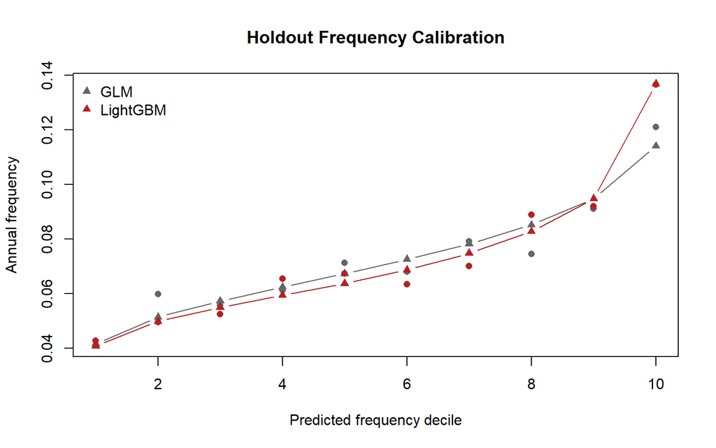

```r
freq_deciles <- results$frequency_deciles
ylim <- range(c(freq_deciles$observed_annual_frequency, freq_deciles$predicted_annual_frequency), na.rm = TRUE)
plot(
  NULL,
  xlim = c(1, 10),
  ylim = ylim,
  xlab = "Predicted frequency decile",
  ylab = "Annual frequency",
  main = "Holdout Frequency Calibration"
)
for (model_name in unique(freq_deciles$model)) {
  rows <- freq_deciles[freq_deciles$model == model_name, ]
  line_col <- ifelse(model_name == "GLM", "gray40", "firebrick")
  points(rows$decile, rows$observed_annual_frequency, pch = 16, col = line_col)
  lines(rows$decile, rows$predicted_annual_frequency, type = "b", pch = 17, col = line_col)
}
legend("topleft", legend = unique(freq_deciles$model), col = c("gray40", "firebrick"), pch = 17, bty = "n")
```

# Severity

Severity is harder because claim amounts are heavy-tailed. The raw model is still useful to inspect, but the capped sensitivity is a more stable view of typical claim severity behavior.

```r
knitr::kable(round_table(severity_comparison))
```

| target | model | observed_mean | predicted_mean | mae | rmse |
| --- | --- | --- | --- | --- | --- |
| Raw severity | GLM | 2402.277 | 2023.484 | 2285.092 | 36294.005 |
| Raw severity | LightGBM | 2402.277 | 1818.943 | 2124.389 | 36291.723 |
| Capped severity | GLM | 1626.456 | 1647.553 | 1224.194 | 3289.422 |
| Capped severity | LightGBM | 1626.456 | 1615.165 | 1200.990 | 3285.865 |

The severity comparison is more cautious. On raw severity, the GLM predicts an average holdout severity of EUR 2,023 versus EUR 2,402 observed, a -15.8% gap. LightGBM predicts EUR 1,819, a -24.3% gap. That is worse aggregate calibration. However, LightGBM lowers raw severity MAE by 7.0%, and in the capped view its mean prediction is within -0.7% of observed capped severity.

My interpretation is that LightGBM finds some body-of-loss signal, but it does not solve the heavy-tail problem. For a portfolio project, that is still useful because it shows the right actuarial caution: the severity model should not be oversold.

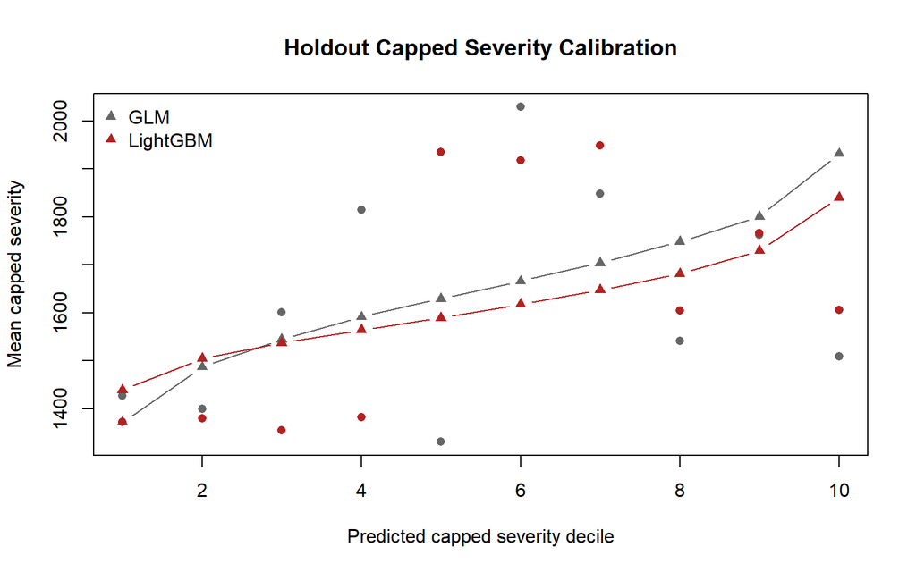

```r
sev_deciles <- results$severity_deciles[results$severity_deciles$target == "Capped severity", ]
ylim <- range(c(sev_deciles$observed_mean, sev_deciles$predicted_mean), na.rm = TRUE)
plot(
  NULL,
  xlim = c(1, 10),
  ylim = ylim,
  xlab = "Predicted capped severity decile",
  ylab = "Mean capped severity",
  main = "Holdout Capped Severity Calibration"
)
for (model_name in unique(sev_deciles$model)) {
  rows <- sev_deciles[sev_deciles$model == model_name, ]
  line_col <- ifelse(model_name == "GLM", "gray40", "firebrick")
  points(rows$decile, rows$observed_mean, pch = 16, col = line_col)
  lines(rows$decile, rows$predicted_mean, type = "b", pch = 17, col = line_col)
}
legend("topleft", legend = unique(sev_deciles$model), col = c("gray40", "firebrick"), pch = 17, bty = "n")
```

# Pure Premium

Pure premium is the business target. At the policy level, observed annual loss cost is noisy because most policies have zero claim cost, but aggregate calibration and decile ranking are still useful.

```r
knitr::kable(round_table(pure_premium_comparison))
```

| target | model | observed_total_loss | predicted_total_loss | observed_loss_cost | predicted_loss_cost | weighted_mae_annual_loss_cost | weighted_rmse_annual_loss_cost | pricing_lift_gini |
| --- | --- | --- | --- | --- | --- | --- | --- | --- |
| Raw severity pure premium | GLM | 7783378 | 6629395 | 167.9057 | 143.0116 | 297.5093 | 20356.92 | 0.2366 |
| Raw severity pure premium | LightGBM | 7783378 | 5864792 | 167.9057 | 126.5173 | 281.5507 | 20355.91 | 0.3957 |
| Capped severity pure premium | GLM | 7783378 | 5345122 | 167.9057 | 115.3068 | 272.1049 | 20357.01 | 0.2128 |
| Capped severity pure premium | LightGBM | 7783378 | 5214071 | 167.9057 | 112.4798 | 268.9606 | 20356.23 | 0.3907 |

Pure premium shows the tradeoff most clearly. The observed holdout loss cost is EUR 168 per exposure-year. The raw GLM pure premium predicts EUR 143, a -14.8% gap. The raw LightGBM pure premium predicts EUR 127, a larger -24.6% gap.

That looks bad if we only care about the unadjusted aggregate level. But the ranking story moves the other way: raw pure premium Gini improves from 0.2366 to 0.3957, a 67.3% relative improvement. This is exactly the distinction an insurer would care about. The GLM gives a more defensible base pricing level; the GBM gives stronger segmentation signal that could identify underpriced and overpriced groups.

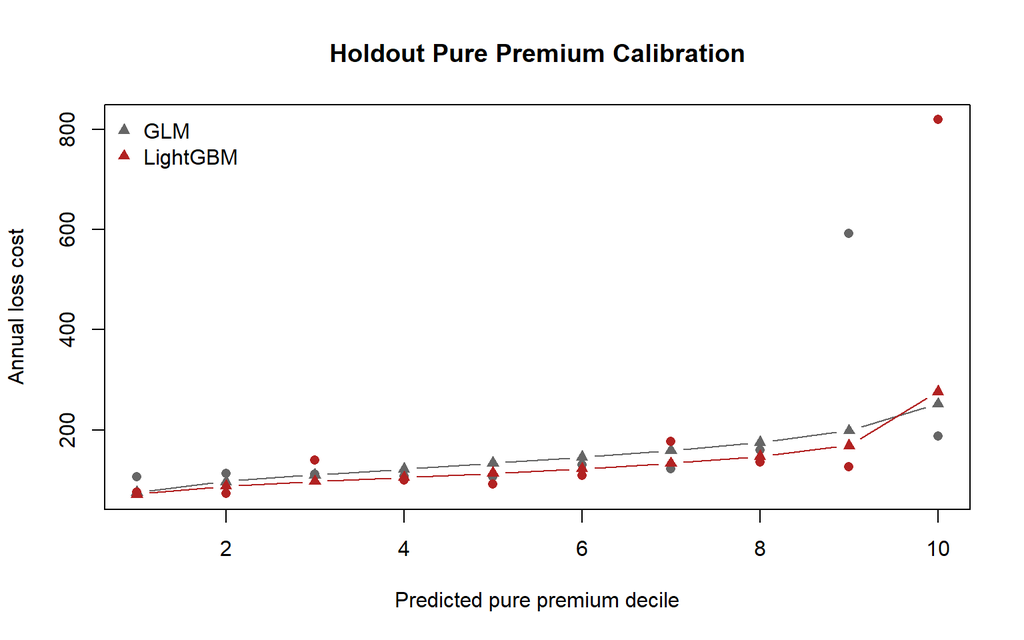

```r
pp_deciles <- results$pure_premium_deciles[results$pure_premium_deciles$target == "Raw severity pure premium", ]
ylim <- range(c(pp_deciles$observed_loss_cost, pp_deciles$predicted_loss_cost), na.rm = TRUE)
plot(
  NULL,
  xlim = c(1, 10),
  ylim = ylim,
  xlab = "Predicted pure premium decile",
  ylab = "Annual loss cost",
  main = "Holdout Pure Premium Calibration"
)
for (model_name in unique(pp_deciles$model)) {
  rows <- pp_deciles[pp_deciles$model == model_name, ]
  line_col <- ifelse(model_name == "GLM", "gray40", "firebrick")
  points(rows$decile, rows$observed_loss_cost, pch = 16, col = line_col)
  lines(rows$decile, rows$predicted_loss_cost, type = "b", pch = 17, col = line_col)
}
legend("topleft", legend = unique(pp_deciles$model), col = c("gray40", "firebrick"), pch = 17, bty = "n")
```

# Feature Importance

Feature importance is not a rate indication. I am using it as a diagnostic for which rating variables the challenger model used most heavily.

```r
cat("## Frequency\n\n")
```

## Frequency

```r
print(knitr::kable(head(round_table(results$importance$frequency), 10)))
```

| Feature | Gain | Cover | Frequency |
| --- | --- | --- | --- |
| DriverAge | 0.3579 | 0.2819 | 0.2046 |
| logDensity | 0.2488 | 0.2432 | 0.2243 |
| CarAge | 0.0960 | 0.1293 | 0.1396 |
| Power | 0.0943 | 0.1018 | 0.1507 |
| Region | 0.0886 | 0.0862 | 0.1412 |
| Brand | 0.0691 | 0.0878 | 0.0981 |
| Gas | 0.0452 | 0.0698 | 0.0415 |

```r
cat("\n\n## Raw Severity\n\n")
```

## Raw Severity

```r
print(knitr::kable(head(round_table(results$importance$severity), 10)))
```

| Feature | Gain | Cover | Frequency |
| --- | --- | --- | --- |
| DriverAge | 0.3637 | 0.3138 | 0.2353 |
| logDensity | 0.1806 | 0.2083 | 0.2559 |
| Power | 0.1353 | 0.1316 | 0.1382 |
| CarAge | 0.1225 | 0.0815 | 0.1490 |
| Region | 0.0809 | 0.1437 | 0.0794 |
| Brand | 0.0786 | 0.1031 | 0.0971 |
| Gas | 0.0384 | 0.0181 | 0.0451 |

```r
cat("\n\n## Capped Severity\n\n")
```

## Capped Severity

```r
print(knitr::kable(head(round_table(results$importance$capped_severity), 10)))
```

| Feature | Gain | Cover | Frequency |
| --- | --- | --- | --- |
| DriverAge | 0.2483 | 0.3075 | 0.2368 |
| logDensity | 0.2082 | 0.2265 | 0.2143 |
| Region | 0.1545 | 0.0847 | 0.1429 |
| CarAge | 0.1514 | 0.1187 | 0.1579 |
| Power | 0.1283 | 0.1344 | 0.1353 |
| Brand | 0.0893 | 0.1184 | 0.0865 |
| Gas | 0.0202 | 0.0098 | 0.0263 |

# Partial Dependence

Partial dependence gives a compact view of nonlinear patterns that a plain GLM may not capture directly.

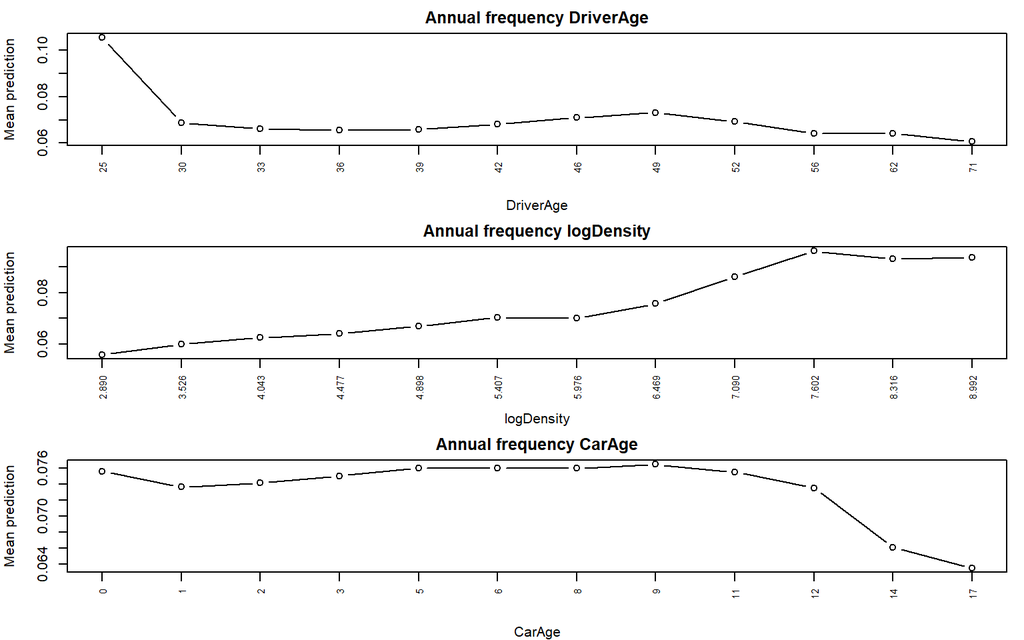

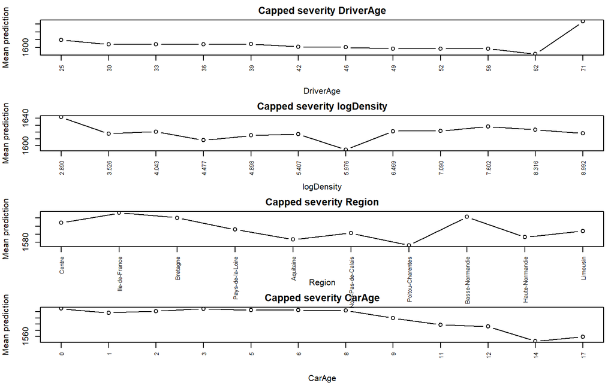

```r
pdp <- results$pdp
for (target_name in unique(pdp$target)) {
  target_rows <- pdp[pdp$target == target_name, ]
  features <- unique(target_rows$feature)
  old_par <- par(mfrow = c(length(features), 1), mar = c(4, 4, 2, 1))
  for (feature_name in features) {
    rows <- target_rows[target_rows$feature == feature_name, ]
    plot(
      seq_len(nrow(rows)),
      rows$mean_prediction,
      type = "b",
      xaxt = "n",
      xlab = feature_name,
      ylab = "Mean prediction",
      main = paste(target_name, feature_name)
    )
    axis(1, at = seq_len(nrow(rows)), labels = rows$value, las = 2, cex.axis = 0.7)
  }
  par(old_par)
}
```

# Interaction Views

These tables are not a production interaction search. They are a sanity check for whether the boosted model is finding patterns worth considering as future GLM feature engineering.

```r
cat("## DriverAge x CarAge\n\n")
```

## DriverAge x CarAge

```r
print(knitr::kable(round_table(results$interactions$driver_car_age)))
```

|  | interaction | DriverAgeBand | CarAgeBand | Exposure | observed_loss_cost | glm_predicted_loss_cost | gbm_predicted_loss_cost |
| --- | --- | --- | --- | --- | --- | --- | --- |
| 18 | DriverAge x CarAge | (35,50] | (10,20] | 5567.9004 | 77.2282 | 135.7263 | 109.0588 |
| 13 | DriverAge x CarAge | (35,50] | (5,10] | 4814.4239 | 101.2609 | 153.0785 | 127.9129 |
| 8 | DriverAge x CarAge | (35,50] | (1,5] | 4461.3831 | 126.1714 | 157.6454 | 127.4524 |
| 19 | DriverAge x CarAge | (50,70] | (10,20] | 4200.5600 | 91.2538 | 107.4194 | 95.4614 |
| 9 | DriverAge x CarAge | (50,70] | (1,5] | 4133.0236 | 117.7934 | 123.6874 | 115.7122 |
| 14 | DriverAge x CarAge | (50,70] | (5,10] | 3927.9942 | 119.8296 | 119.7378 | 113.6888 |
| 12 | DriverAge x CarAge | (25,35] | (5,10] | 2789.0874 | 137.0531 | 189.1687 | 139.1538 |
| 17 | DriverAge x CarAge | (25,35] | (10,20] | 2754.7522 | 77.7812 | 164.4867 | 114.5638 |
| 7 | DriverAge x CarAge | (25,35] | (1,5] | 2413.6737 | 230.2660 | 196.4330 | 137.3861 |
| 3 | DriverAge x CarAge | (35,50] | [-Inf,1] | 1957.0668 | 154.4986 | 153.9601 | 125.8454 |
| 4 | DriverAge x CarAge | (50,70] | [-Inf,1] | 1828.7216 | 125.5937 | 121.9637 | 116.5749 |
| 20 | DriverAge x CarAge | (70,Inf] | (10,20] | 1125.2664 | 64.9944 | 77.0777 | 89.2388 |
| 15 | DriverAge x CarAge | (70,Inf] | (5,10] | 1045.1773 | 233.9019 | 89.1589 | 119.1316 |
| 10 | DriverAge x CarAge | (70,Inf] | (1,5] | 1035.7228 | 189.9166 | 93.4513 | 127.9741 |
| 2 | DriverAge x CarAge | (25,35] | [-Inf,1] | 989.6998 | 86.2140 | 186.8392 | 133.4368 |
| 16 | DriverAge x CarAge | [17,25] | (10,20] | 797.1587 | 2901.8113 | 188.4253 | 318.0075 |

```r
cat("\n\n## Power x Brand\n\n")
```

## Power x Brand

```r
print(knitr::kable(round_table(results$interactions$power_brand)))
```

|  | interaction | Power | Brand | Exposure | observed_loss_cost | glm_predicted_loss_cost | gbm_predicted_loss_cost |
| --- | --- | --- | --- | --- | --- | --- | --- |
| 62 | Power x Brand | f | Renault, Nissan or Citroen | 7725.3058 | 120.6788 | 174.6781 | 131.3983 |
| 63 | Power x Brand | g | Renault, Nissan or Citroen | 6475.6952 | 158.3578 | 127.7024 | 121.3030 |
| 61 | Power x Brand | e | Renault, Nissan or Citroen | 5100.5579 | 100.9942 | 129.0471 | 115.2605 |
| 60 | Power x Brand | d | Renault, Nissan or Citroen | 4454.4949 | 97.5258 | 116.5032 | 110.7200 |
| 38 | Power x Brand | e | Opel, General Motors or Ford | 1499.1385 | 173.3289 | 130.7630 | 135.2939 |
| 16 | Power x Brand | g | Japanese (except Nissan) or Korean | 1294.1600 | 123.6532 | 122.3672 | 120.1552 |
| 13 | Power x Brand | d | Japanese (except Nissan) or Korean | 1263.9753 | 148.3130 | 115.4015 | 117.2129 |
| 64 | Power x Brand | h | Renault, Nissan or Citroen | 1173.3659 | 90.4739 | 124.9267 | 113.7047 |
| 73 | Power x Brand | e | Volkswagen, Audi, Skoda or Seat | 1116.7575 | 93.5127 | 174.7488 | 143.7480 |
| 74 | Power x Brand | f | Volkswagen, Audi, Skoda or Seat | 1116.4695 | 67.9956 | 235.9448 | 170.3739 |
| 15 | Power x Brand | f | Japanese (except Nissan) or Korean | 902.9823 | 125.1287 | 161.1857 | 132.9637 |
| 65 | Power x Brand | i | Renault, Nissan or Citroen | 895.0058 | 2380.0806 | 131.0681 | 126.6613 |
| 40 | Power x Brand | g | Opel, General Motors or Ford | 850.9402 | 169.0941 | 131.9523 | 152.5468 |
| 14 | Power x Brand | e | Japanese (except Nissan) or Korean | 776.8950 | 51.5797 | 122.0240 | 110.6932 |
| 37 | Power x Brand | d | Opel, General Motors or Ford | 749.4774 | 95.9722 | 119.7922 | 117.9062 |
| 39 | Power x Brand | f | Opel, General Motors or Ford | 694.4157 | 91.5633 | 178.9790 | 138.3959 |

```r
cat("\n\n## Region x logDensity\n\n")
```

## Region x logDensity

```r
print(knitr::kable(round_table(results$interactions$region_density)))
```

|  | interaction | Region | DensityBand | Exposure | observed_loss_cost | glm_predicted_loss_cost | gbm_predicted_loss_cost |
| --- | --- | --- | --- | --- | --- | --- | --- |
| 3 | Region x logDensity | Centre | [1.1,4.22] | 9252.1831 | 128.4259 | 129.7302 | 100.5641 |
| 9 | Region x logDensity | Centre | (4.22,5.67] | 5429.9334 | 459.3427 | 148.4543 | 110.4895 |
| 15 | Region x logDensity | Centre | (5.67,7.26] | 4718.2113 | 143.5881 | 171.2149 | 147.7476 |
| 22 | Region x logDensity | Ile-de-France | (7.26,10.2] | 4448.2141 | 161.0723 | 157.4506 | 146.9375 |
| 8 | Region x logDensity | Bretagne | (4.22,5.67] | 2227.4423 | 88.6128 | 146.8320 | 112.4525 |
| 14 | Region x logDensity | Bretagne | (5.67,7.26] | 1977.7368 | 81.2333 | 159.6719 | 129.7084 |
| 18 | Region x logDensity | Pays-de-la-Loire | (5.67,7.26] | 1474.8676 | 98.8733 | 126.8954 | 134.0443 |
| 12 | Region x logDensity | Pays-de-la-Loire | (4.22,5.67] | 1296.8033 | 80.5558 | 112.4805 | 113.0211 |
| 21 | Region x logDensity | Centre | (7.26,10.2] | 1083.5721 | 179.3152 | 202.2612 | 193.0435 |
| 16 | Region x logDensity | Ile-de-France | (5.67,7.26] | 1015.0579 | 158.4461 | 132.5082 | 140.8817 |
| 17 | Region x logDensity | Nord-Pas-de-Calais | (5.67,7.26] | 934.1340 | 108.7435 | 140.1091 | 142.0520 |
| 24 | Region x logDensity | Pays-de-la-Loire | (7.26,10.2] | 863.0639 | 136.0120 | 145.7622 | 153.9368 |
| 23 | Region x logDensity | Nord-Pas-de-Calais | (7.26,10.2] | 853.6268 | 202.6740 | 155.2768 | 157.0894 |
| 19 | Region x logDensity | Aquitaine | (7.26,10.2] | 828.1774 | 150.7020 | 163.6588 | 164.7680 |
| 7 | Region x logDensity | Aquitaine | (4.22,5.67] | 810.8676 | 139.8773 | 125.5789 | 126.1203 |
| 2 | Region x logDensity | Bretagne | [1.1,4.22] | 775.8622 | 69.8591 | 136.6417 | 103.2148 |

# GBM-To-GLM Synthesis

The order matters in this section. I first ran the full LightGBM analysis above, including the performance comparison, feature importance, PDPs, and interaction views. Only after that did I translate the GBM findings into explicit GLM terms and test whether those terms improved a transparent actuarial model.

The decision logic was:

- use the GBM as a diagnostic model, not as the final pricing model
- test spline terms where PDP and importance suggested nonlinear continuous effects
- test only the interaction families reviewed in the GBM section
- keep an enhanced GLM term only when it improved the relevant holdout metric without creating an unacceptable calibration deterioration
- document rejected terms directly

```r
knitr::kable(results$gbm_learning_summary)
```

| area | gbm_learning | synthesis_action |
| --- | --- | --- |
| Frequency ranking | Yes, frequency Gini improved meaningfully. | Test enhanced frequency GLM terms against holdout ranking and calibration. |
| Pure premium ranking | Yes, pure-premium Gini improved meaningfully. | Evaluate whether enhanced pure premium captures more GBM ranking signal while retaining GLM transparency. |
| Severity calibration | No. Severity remains tail-sensitive, so raw and capped views should both be shown. | Keep raw and capped severity views separate and require holdout MAE/RMSE support before adding complexity. |
| Candidate nonlinear shapes | PDP/importance focus: frequency top features were DriverAge, logDensity, CarAge, Power, Region; capped severity top features were DriverAge, logDensity, Region, CarAge, Power. | Test natural splines for DriverAge, CarAge, and logDensity. |
| Candidate interactions | Interaction review focused on DriverAge x CarAge, Power x Brand, and Region x logDensity. | Test banded and categorical interactions explicitly. |

The enhanced GLM candidate set was intentionally small. I tested natural splines for `DriverAge`, `CarAge`, and `logDensity`, plus three interaction families: `DriverAgeBand x CarAgeBand`, `Power x Brand`, and `Region x DensityBand`.

For frequency, the primary selection metric is pricing lift Gini because the GBM’s strongest contribution was ranking and segmentation. For severity, the primary selection metric is MAE because the severity problem is tail-sensitive and aggregate mean calibration alone is too volatile.

```r
term_decisions_display <- results$term_decisions
term_decisions_display$primary_metric_before <- round(term_decisions_display$primary_metric_before, 4)
term_decisions_display$primary_metric_after <- round(term_decisions_display$primary_metric_after, 4)
term_decisions_display$primary_metric_delta <- round(term_decisions_display$primary_metric_delta, 4)
term_decisions_display$calibration_gap_before <- sprintf("%.1f%%", 100 * term_decisions_display$calibration_gap_before)
term_decisions_display$calibration_gap_after <- sprintf("%.1f%%", 100 * term_decisions_display$calibration_gap_after)
knitr::kable(term_decisions_display)
```

| component | candidate | decision | primary_metric_before | primary_metric_after | primary_metric_delta | calibration_gap_before | calibration_gap_after |
| --- | --- | --- | --- | --- | --- | --- | --- |
| Frequency | Natural splines for DriverAge, CarAge, and logDensity | Accepted | 0.1466 | 0.1746 | 0.0280 | -0.2% | -0.3% |
| Frequency | DriverAgeBand x CarAgeBand | Rejected | 0.1746 | 0.1740 | -0.0005 | -0.3% | -0.4% |
| Frequency | Power x Brand | Accepted | 0.1746 | 0.1778 | 0.0032 | -0.3% | -0.4% |
| Frequency | Region x DensityBand | Accepted | 0.1778 | 0.1802 | 0.0023 | -0.4% | -0.4% |
| Raw severity | Natural splines for DriverAge, CarAge, and logDensity | Accepted | 2285.0922 | 2282.7473 | -2.3450 | -15.8% | -16.1% |
| Raw severity | DriverAgeBand x CarAgeBand | Rejected | 2282.7473 | 2298.2154 | 15.4682 | -16.1% | -15.8% |
| Raw severity | Power x Brand | Rejected | 2282.7473 | 2292.7965 | 10.0492 | -16.1% | -16.2% |
| Raw severity | Region x DensityBand | Rejected | 2282.7473 | 2290.1496 | 7.4024 | -16.1% | -16.0% |
| Capped severity | Natural splines for DriverAge, CarAge, and logDensity | Rejected | 1224.1941 | 1225.3577 | 1.1636 | 1.3% | 1.4% |
| Capped severity | DriverAgeBand x CarAgeBand | Rejected | 1224.1941 | 1228.3929 | 4.1988 | 1.3% | 1.3% |
| Capped severity | Power x Brand | Rejected | 1224.1941 | 1229.3057 | 5.1116 | 1.3% | 1.2% |
| Capped severity | Region x DensityBand | Rejected | 1224.1941 | 1225.7684 | 1.5742 | 1.3% | 1.3% |

```r
knitr::kable(results$enhanced_formulas)
```

| component | formula | accepted_interactions | uses_splines |
| --- | --- | --- | --- |
| Frequency | ClaimNb ~ Power + Brand + Gas + Region + splines::ns(DriverAge, df = 4) + splines::ns(CarAge, df = 4) + splines::ns(logDensity, df = 4) + Power:Brand + Region:DensityBand + offset(LogExposure) | Power:Brand, Region:DensityBand | TRUE |
| Raw severity | ClaimAmount ~ Power + Brand + Gas + Region + splines::ns(DriverAge, df = 4) + splines::ns(CarAge, df = 4) + splines::ns(logDensity, df = 4) | None | TRUE |
| Capped severity | ClaimAmountCapped ~ Power + Brand + Gas + Region + DriverAge + CarAge + logDensity | None | FALSE |

The result is a selective synthesis rather than a blind import of all GBM complexity:

- frequency accepted the continuous splines, `Power x Brand`, and `Region x DensityBand`
- raw severity accepted only the continuous splines
- capped severity rejected all tested additions, so it stayed at the baseline GLM structure

```r
knitr::kable(round_table(results$synthesis_checks))
```

| metric | value |
| --- | --- |
| frequency_holdout_alignment_failures | 0 |
| severity_holdout_alignment_failures | 0 |
| enhanced_frequency_nonfinite_predictions | 0 |
| enhanced_raw_severity_nonfinite_predictions | 0 |
| enhanced_capped_severity_nonfinite_predictions | 0 |
| observed_loss_reconciliation_gap | 0 |

# Synthesis Results

The enhanced GLM improved the baseline GLM’s segmentation while keeping the model transparent. Frequency Gini increased from 0.1466 to 0.1802, a 22.9% relative lift. LightGBM still edges it at 0.1816, but the enhanced GLM captures most of the GBM’s frequency-ranking improvement with explicit model terms.

```r
knitr::kable(round_table(synthesis_frequency_comparison))
```

| model | observed_claims | predicted_claims | observed_annual_frequency | predicted_annual_frequency | weighted_mae_annual_frequency | weighted_rmse_annual_frequency | pricing_lift_gini |
| --- | --- | --- | --- | --- | --- | --- | --- |
| Baseline GLM | 3240 | 3233.804 | 0.0699 | 0.0698 | 0.1327 | 0.4694 | 0.1466 |
| Enhanced GLM | 3240 | 3228.290 | 0.0699 | 0.0696 | 0.1323 | 0.4690 | 0.1802 |
| LightGBM | 3240 | 3226.221 | 0.0699 | 0.0696 | 0.1322 | 0.4689 | 0.1816 |

Severity improved only modestly. The raw enhanced GLM reduced MAE versus the baseline GLM, but LightGBM remained better on raw and capped severity MAE. The capped severity GLM did not benefit from the tested terms, so the selection process left it unchanged.

```r
knitr::kable(round_table(synthesis_severity_comparison))
```

| target | model | observed_mean | predicted_mean | mae | rmse |
| --- | --- | --- | --- | --- | --- |
| Raw severity | Baseline GLM | 2402.277 | 2023.484 | 2285.092 | 36294.005 |
| Raw severity | Enhanced GLM | 2402.277 | 2016.067 | 2282.747 | 36271.597 |
| Raw severity | LightGBM | 2402.277 | 1818.943 | 2124.389 | 36291.723 |
| Capped severity | Baseline GLM | 1626.456 | 1647.553 | 1224.194 | 3289.422 |
| Capped severity | Enhanced GLM | 1626.456 | 1647.553 | 1224.194 | 3289.422 |
| Capped severity | LightGBM | 1626.456 | 1615.165 | 1200.990 | 3285.865 |

Pure premium is the main business target. The raw enhanced GLM improved pricing lift Gini from 0.2366 to 0.3484, a 47.3% relative lift over the baseline GLM. LightGBM remains stronger at 0.3957, but it also has the weakest aggregate loss-cost calibration.

```r
knitr::kable(round_table(synthesis_pure_premium_comparison))
```

| target | model | observed_total_loss | predicted_total_loss | observed_loss_cost | predicted_loss_cost | weighted_mae_annual_loss_cost | weighted_rmse_annual_loss_cost | pricing_lift_gini |
| --- | --- | --- | --- | --- | --- | --- | --- | --- |
| Raw severity pure premium | Baseline GLM | 7783378 | 6629395 | 167.9057 | 143.0116 | 297.5093 | 20356.92 | 0.2366 |
| Raw severity pure premium | Enhanced GLM | 7783378 | 6573784 | 167.9057 | 141.8120 | 295.3947 | 20355.78 | 0.3484 |
| Raw severity pure premium | LightGBM | 7783378 | 5864792 | 167.9057 | 126.5173 | 281.5507 | 20355.91 | 0.3957 |
| Capped severity pure premium | Baseline GLM | 7783378 | 5345122 | 167.9057 | 115.3068 | 272.1049 | 20357.01 | 0.2128 |
| Capped severity pure premium | Enhanced GLM | 7783378 | 5335658 | 167.9057 | 115.1027 | 271.4213 | 20356.56 | 0.3791 |
| Capped severity pure premium | LightGBM | 7783378 | 5214071 | 167.9057 | 112.4798 | 268.9606 | 20356.23 | 0.3907 |

The aggregate loss-cost tradeoff is important. The observed holdout loss cost is EUR 168. The baseline GLM predicts EUR 143, a -14.8% gap. The enhanced GLM predicts EUR 142, a -15.5% gap. LightGBM predicts EUR 127, a -24.6% gap.

So the synthesis does not solve aggregate underprediction. Its business value is risk segmentation: the enhanced GLM identifies a much more loss-heavy high-risk group than the baseline GLM.

```r
knitr::kable(round_table(high_risk_decile_summary))
```

| model | exposure_share | observed_loss_capture_share | observed_loss_cost | predicted_loss_cost | observed_lift_vs_portfolio |
| --- | --- | --- | --- | --- | --- |
| Baseline GLM | 0.0869 | 0.0968 | 187.0786 | 251.5166 | 1.1142 |
| Enhanced GLM | 0.0810 | 0.3810 | 789.3165 | 371.6714 | 4.7010 |
| LightGBM | 0.0793 | 0.3865 | 818.7609 | 276.5612 | 4.8763 |

In the top predicted pure-premium decile, the baseline GLM captures 9.7% of observed holdout loss with observed lift of 1.11 times the portfolio average. The enhanced GLM captures 38.1% with observed lift of 4.7 times. LightGBM captures 38.6% with observed lift of 4.88 times.

```r
business_impact_display <- business_impact
business_impact_display[business_impact_display$metric %in% c(
  "Raw aggregate loss calibration gap",
  "Top-decile observed loss capture"
), c("baseline_glm", "enhanced_glm", "lightgbm")] <- lapply(
  business_impact_display[business_impact_display$metric %in% c(
    "Raw aggregate loss calibration gap",
    "Top-decile observed loss capture"
  ), c("baseline_glm", "enhanced_glm", "lightgbm")],
  function(x) round(100 * x, 2)
)
knitr::kable(round_table(business_impact_display))
```

| metric | baseline_glm | enhanced_glm | lightgbm |
| --- | --- | --- | --- |
| Frequency Gini | 0.1466 | 0.1802 | 0.1816 |
| Raw pure premium Gini | 0.2366 | 0.3484 | 0.3957 |
| Raw predicted loss cost | 143.0116 | 141.8120 | 126.5173 |
| Raw aggregate loss calibration gap | -14.8300 | -15.5400 | -24.6500 |
| Top-decile observed loss capture | 9.6800 | 38.1000 | 38.6500 |
| Top-decile observed lift | 1.1142 | 4.7010 | 4.8763 |

# Conclusion

The final question is whether LightGBM adds actuarial value beyond the GLM, and whether that value can be synthesized back into a transparent actuarial model. My answer is yes, but with a clear split between ranking value and calibration value.

The baseline GLM is still the clean benchmark. It is simple, easy to explain, and strong on aggregate frequency calibration. On holdout frequency, it predicts 3,233.8 claims against 3,240 observed. The GBM showed that the baseline GLM was smoothing over useful segmentation signal, especially in frequency and pure premium ranking.

The enhanced GLM captures a meaningful part of that GBM signal. Frequency Gini rises from 0.1466 for the baseline GLM to 0.1802 for the enhanced GLM. Raw pure premium Gini rises from 0.2366 to 0.3484. That improvement comes from explicit, reviewable terms: continuous splines for nonlinear feature shape, plus selected frequency interactions for `Power x Brand` and `Region x DensityBand`.

The tradeoff is calibration. The enhanced GLM does not improve aggregate raw loss-cost calibration; it predicts EUR 142 versus EUR 168 observed. LightGBM is even more undercalibrated as a direct pricing level. Severity remains the limiting component: LightGBM improves severity MAE, but neither GBM nor the enhanced GLM solves the heavy-tail problem.

The business impact of synthesis is strongest in portfolio segmentation. The enhanced GLM’s top predicted pure-premium decile captures 38.1% of observed holdout loss, versus 9.7% for the baseline GLM. That is a material improvement for pricing review and underwriting triage, even though an aggregate calibration adjustment would still be required before using the model as a direct rate level.

My recommendation is to keep the enhanced GLM as the transparent synthesis model, keep LightGBM as the challenger and discovery layer, and treat aggregate loss-cost calibration as a separate actuarial adjustment. The synthesis improves the baseline GLM where the GBM was strongest: ranking, segmentation, and identifying high-loss pockets. It does not eliminate the need for severity caution or calibration governance.

For this side project, the strongest final story is not “GBM beats GLM.” It is “GBM revealed nonlinear and interaction signal, and a selective enhanced GLM captured a meaningful share of that signal while preserving transparency.”